# Car Prices

## Background

When buying a car you have to look at the initial price and also guess what the depreciation of the price will be once bought. With the data provided we can take a look at a certain car brand, Buick, and predict the depreciation on the model based on the mileage it has driven. We want to be able to predict the price of any Buick with a certain mileage in mind.

```r
BPrices <- CarPrices %>%
 filter(Make == "Buick")

datatable(BPrices)
```

|  | Price | Mileage | Make | Model | Trim | Type | Cylinder | Liter | Doors | Cruise | Sound | Leather |
| --- | --- | --- | --- | --- | --- | --- | --- | --- | --- | --- | --- | --- |
| 1 | 17314.10313 | 8221 | Buick | Century | Sedan 4D | Sedan | 6 | 3.1 | 4 | 1 | 1 | 1 |
| 2 | 17542.03608 | 9135 | Buick | Century | Sedan 4D | Sedan | 6 | 3.1 | 4 | 1 | 1 | 0 |
| 3 | 16218.84786 | 13196 | Buick | Century | Sedan 4D | Sedan | 6 | 3.1 | 4 | 1 | 1 | 0 |
| 4 | 16336.91314 | 16342 | Buick | Century | Sedan 4D | Sedan | 6 | 3.1 | 4 | 1 | 0 | 0 |
| 5 | 16339.17032 | 19832 | Buick | Century | Sedan 4D | Sedan | 6 | 3.1 | 4 | 1 | 0 | 1 |
| 6 | 15709.05282 | 22236 | Buick | Century | Sedan 4D | Sedan | 6 | 3.1 | 4 | 1 | 1 | 0 |
| 7 | 15230.00339 | 22576 | Buick | Century | Sedan 4D | Sedan | 6 | 3.1 | 4 | 1 | 1 | 0 |
| 8 | 15048.04218 | 22964 | Buick | Century | Sedan 4D | Sedan | 6 | 3.1 | 4 | 1 | 1 | 0 |
| 9 | 14862.09387 | 24021 | Buick | Century | Sedan 4D | Sedan | 6 | 3.1 | 4 | 1 | 0 | 1 |
| 10 | 15295.01827 | 27325 | Buick | Century | Sedan 4D | Sedan | 6 | 3.1 | 4 | 1 | 1 | 1 |

[output cut: 70 more lines]

```r
blm <- lm(Price ~ Mileage + Model, data = BPrices)
```

## Analysis

Since we want to be able to predict the cars price after a certain mileage, we will write the equation as such:
$$Y_i = \beta_0 + \beta_1 X_{i1} + \beta_2 X_{i2} + \beta_3 X_{i3} + \beta_4 X_{i4} + \epsilon_i$$

Below is a plot that demonstrates the relationship between the price of the car and the mileage. This graph shows each Buick car that is presented in our datatable from above.

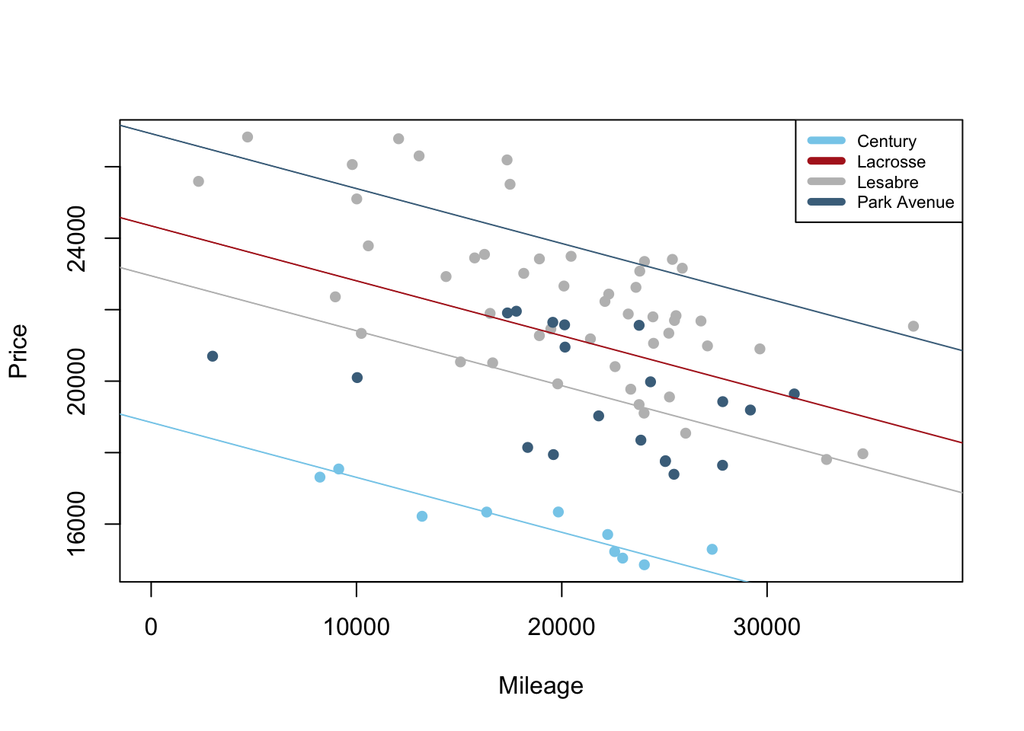

```r
palette(c("skyblue", "firebrick", "gray", "skyblue4"))
plot(Price ~ Mileage, data = BPrices, pch = 16, col = BPrices$Model, xlim=c(0,38000))
abline(blm$coef[1] , blm$coef[2], col = palette()[1])
abline(blm$coef[1]+blm$coef[3], blm$coef[2], col = palette()[2])
abline(blm$coef[1]+blm$coef[4], blm$coef[2], col = palette()[3])
abline(blm$coef[1]+blm$coef[5], blm$coef[2], col = palette()[4])
legend("topright", blm$xlevels$Model, lty = 1, lwd = 5, col = palette(), cex = 0.7)
```

With our regression model we can see the intercepts which will tell us in depth how much we are losing or gaining in price. Our mileage estimate is -0.15 which translates to a depreciation of $0.15 per mile.

```r
pander(summary(blm))
```

|  | Estimate | Std. Error | t value | Pr(>\|t\|) |
| --- | --- | --- | --- | --- |
| **(Intercept)** | 18847 | 526.2 | 35.81 | 6.46e-49 |
| **Mileage** | -0.1537 | 0.01971 | -7.799 | 2.879e-11 |
| **ModelLacrosse** | 5501 | 439.4 | 12.52 | 4.712e-20 |
| **ModelLesabre** | 4103 | 466.4 | 8.798 | 3.607e-13 |
| **ModelPark Avenue** | 8082 | 462.7 | 17.47 | 3.784e-28 |

Fitting linear model: Price ~ Mileage + Model

| Observations | Residual Std. Error | $R^2$ | Adjusted $R^2$ |
| --- | --- | --- | --- |
| 80 | 1195 | 0.8382 | 0.8296 |

Our regression summary shows us that the cars will lose an average of $0.15 per mile.

## Assumption

Looking at our Q-Q plot, we can see some discrepencies. Our Q-Q plot is questionable and shows that some of the data may not be linear. This can be due to other factors of cars and the resale value. Resale value can be affected by car accident history, which isn’t relevant towards the mileage. It can also be affected by modifications to the car, which again is not influenced by the mileage.

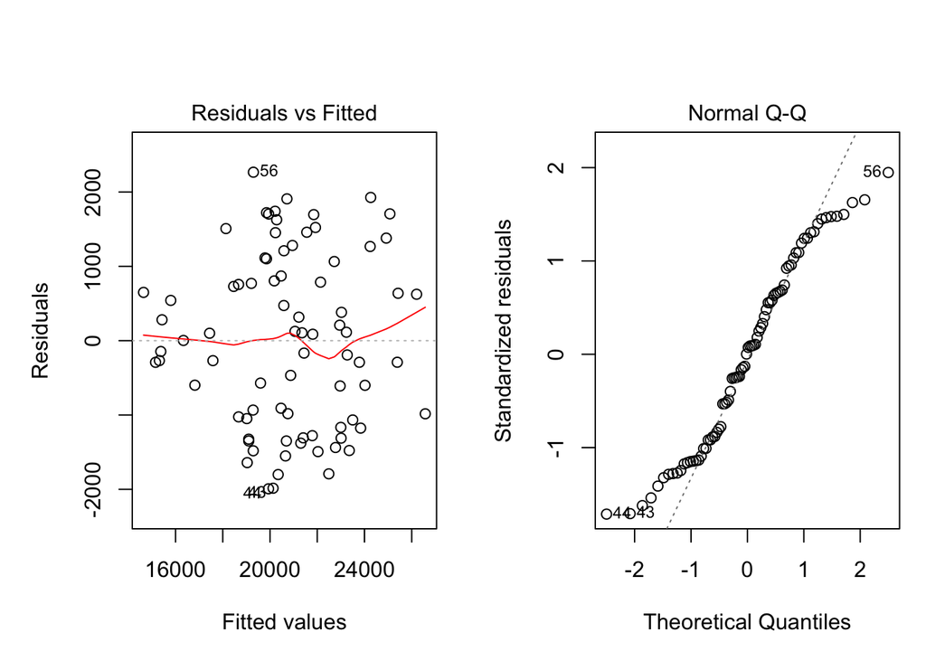

```r
par(mfrow=c(1,2), mai =c(1,1,1,.2))
plot(blm, which = 1:2)
```

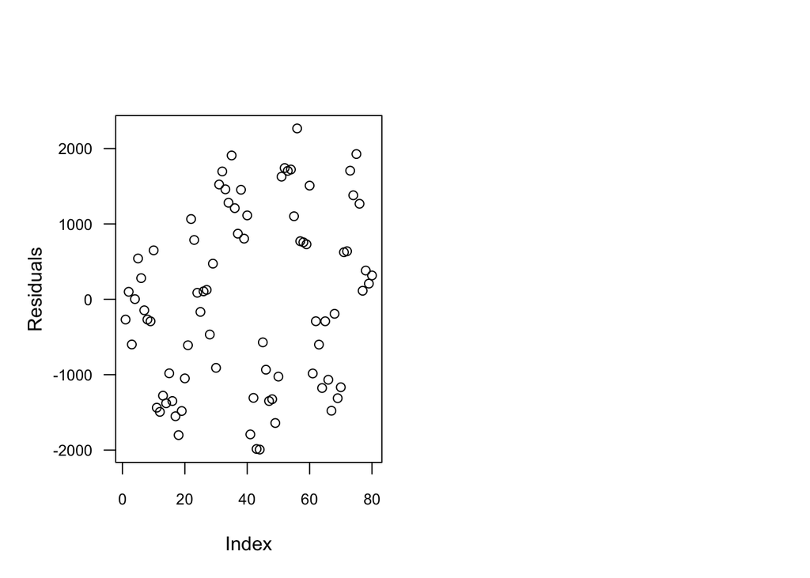

```r
plot(blm$residuals, ylab = "Residuals", las=1, cex.axis=.8)
```